# stan ingredients

Each function is called using the same language as Stan, allowing you to use this as a quick reference guide for the look of a given distribution and decide if its an appropriate fit for your data.

Every plot contains the same set of distributions found on the wikipedia page examples of the given distribution.

Documentation on all Stan distributions can be found in Chapter IX of the [Stan Reference Guide](http://mc-stan.org/users/documentation/).

Hope you find this helpful! You can find me on: [Github](https://github.com/ojhall94]) | [Twitter](https://twitter.com/ojhall94) | ojhall94-at-gmail-dot-com

```python
import numpy as np
import matplotlib.pyplot as plt
import seaborn as sns
```

In the majority (but not all!) of cases, the following holds true:

$\mu$ = the position of the distribution

$\sigma$ = the spread of the distribution.

I have followed the nomenclature used int eh Stan Reference Guide.

# Unbounded Continuous Distributions

## Normal Distribution

$y \sim \textbf{normal}(\textit{mu, sigma})$

```python
def normal(x, mu, sigma):
    return (1/np.sqrt(2*np.pi*sigma**2)) * np.exp(-(x - mu)**2/(2*sigma**2))
```

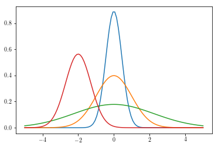

```python
x = np.linspace(-5,5,100)
plt.plot(x, normal(x, 0, np.sqrt(0.2)))
plt.plot(x, normal(x, 0, np.sqrt(1.0)))
plt.plot(x, normal(x, 0, np.sqrt(5.0)))
plt.plot(x, normal(x, -2, np.sqrt(0.5)))
plt.show()
```

## Exponentially Modified Normal Distribution

$y \sim \textbf{exp\_mod\_normal}(\textit{mu, sigma, lambda})$

```python
from scipy.special import erfc

def exp_mod_normal(x, mu, sigma, lambd):
    A = (lambd/2) * np.exp((lambd/2)*(2*mu+lambd*sigma**2-2*x))
    return A*erfc((mu+lambd*sigma**2-x)/(np.sqrt(2)*sigma))
```

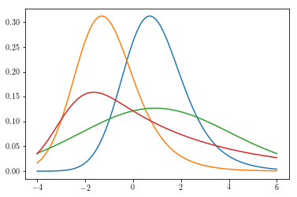

```python
x = np.linspace(-4,6,100)
plt.plot(x, exp_mod_normal(x, 0, 1., 1.))
plt.plot(x, exp_mod_normal(x, -2, 1., 1.))
plt.plot(x, exp_mod_normal(x, 0, 3., 1.))
plt.plot(x, exp_mod_normal(x, -3, 1., 0.25))

plt.show()
```

## Skew Normal Distribution

$y \sim \textbf{skew\_normal}(\textit{xi, omega, alpha})$

```python
from scipy.special import erf

def skew_normal(x, xi, omega, alpha):
    A = (1/omega*np.sqrt(2*np.pi)) * np.exp(-0.5*((x-xi)/omega)**2)
    return A * (1+erf(alpha*((x-xi)/(omega*np.sqrt(2)))))
```

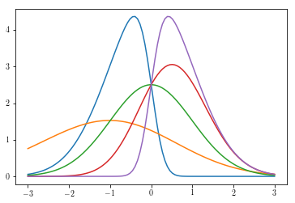

```python
x = np.linspace(-3,3,100)
plt.plot(x, skew_normal(x, 0., 1., -4.))
plt.plot(x, skew_normal(x, 0., 2., -1.))
plt.plot(x, skew_normal(x, 0., 1., 0.))
plt.plot(x, skew_normal(x, 0., 1., 1.))
plt.plot(x, skew_normal(x, 0., 1., 4.))
plt.show()
```

## Student-t Distribution

$y \sim \textbf{student\_t}(\textit{nu, mu, sigma})$

```python
from scipy.stats import t

def student_t(x, nu, mu, sigma):
    return t.pdf(x, nu, mu, sigma)
```

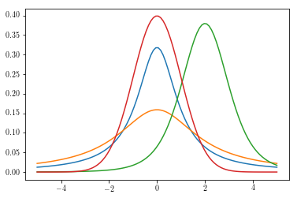

```python
x = np.linspace(-5,5,100)
plt.plot(x, student_t(x, 1., 0., 1.))
plt.plot(x, student_t(x, 1., 0., 2.))
plt.plot(x, student_t(x, 5., 2., 1.))
plt.plot(x, student_t(x, 1e6, 0., 1.))
plt.show()
```

## Cauchy (Lorentzian) Distribution

$y \sim \textbf{cauchy}(\textit{mu, sigma})$

```python
def cauchy(x, mu, sigma):
    return 1/(np.pi*sigma*(1+((x-mu)/sigma)**2))
```

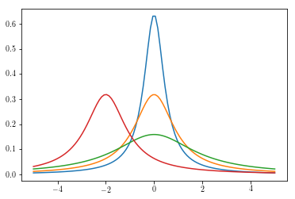

```python
x = np.linspace(-5,5,100)
plt.plot(x, cauchy(x, 0., 0.5))
plt.plot(x, cauchy(x, 0., 1.))
plt.plot(x, cauchy(x, 0., 2.))
plt.plot(x, cauchy(x, -2., 1.))
plt.show()
```

## Double Exponential (Laplace) Distribution

$y \sim \textbf{double\_exponential}(\textit{mu, sigma})$

```python
def double_exponential(x, mu, sigma):
    return (1./(2.*sigma))*np.exp(-np.abs(x-mu)/sigma)
```

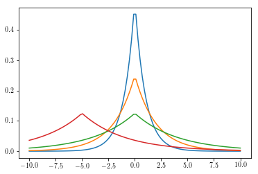

```python
x = np.linspace(-10,10,100)
plt.plot(x, double_exponential(x, 0.,1))
plt.plot(x, double_exponential(x, 0., 2))
plt.plot(x, double_exponential(x, 0., 4))
plt.plot(x, double_exponential(x, -5., 4))
plt.show()
```

## Logistic Distribution

$y \sim \textbf{logistic}(\textit{mu, sigma})$

```python
def logistic(x, mu, sigma):
    return (1./sigma)*np.exp(-(x-mu)/sigma) * (1.+np.exp(-(x-mu)/sigma))**-2
```

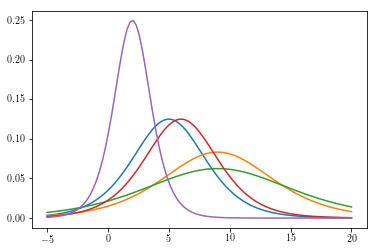

```python
x = np.linspace(-5,20,100)
plt.plot(x, logistic(x, 5.,2.))
plt.plot(x, logistic(x, 9.,3.))
plt.plot(x, logistic(x, 9.,4.))
plt.plot(x, logistic(x, 6.,2.))
plt.plot(x, logistic(x, 2.,1.))
plt.show()
```

## Gumbel Distribution

$y \sim \textbf{gumbel}(\textit{mu, beta})$

```python
def gumbel(x, mu, beta):
    return (1/beta)*np.exp(-(x-mu)/beta - np.exp(-(x-mu)/beta))
```

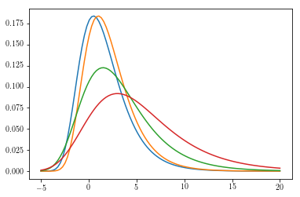

```python
x = np.linspace(-5,20,100)
plt.plot(x, gumbel(x,.5,2.))
plt.plot(x, gumbel(x, 1.,2.))
plt.plot(x, gumbel(x, 1.5,3.))
plt.plot(x, gumbel(x, 3.,4.))
plt.show()
```

# Positive Continuous Distributions

## Lognormal Distribution

$y \sim \textbf{lognormal}(\textit{mu, sigma})$

```python
def lognormal(x, mu, sigma):
    A = (1/np.sqrt(2*np.pi*sigma**2)) * (1/x)
    return  A * np.exp(-0.5*((np.log(x)-mu)/sigma)**2)
```

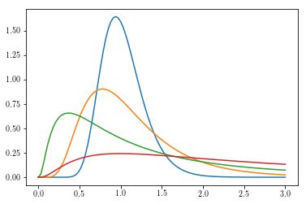

```python
x = np.linspace(0.0001,3,100)
plt.plot(x, lognormal(x,0.,.25))
plt.plot(x, lognormal(x,0.,.5))
plt.plot(x, lognormal(x,0.,1.))
plt.plot(x, lognormal(x,1.,1.))
plt.show()
```

## Chi-Square Distribution

$y \sim \textbf{chi\_square}(\textit{nu})$

```python
from scipy.stats import chi2
def chi_square(x, nu):
    return chi2.pdf(x, nu)
```

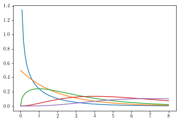

```python
x = np.linspace(0.,8,100)
plt.plot(x, chi_square(x, 1.))
plt.plot(x, chi_square(x, 2.))
plt.plot(x, chi_square(x, 3.))
plt.plot(x, chi_square(x, 6.))
plt.plot(x, chi_square(x, 9.))
plt.show()
```

## Inverse Chi-Square Distribution

$y \sim \textbf{inv\_chi\_square}(\textit{nu})$

```python
from scipy.special import gamma as gammafn
def inv_chi_square(x, nu):
    A = (2**(-nu/2)/gammafn(nu/2)) * x**(-nu/2 -1)
    return A * np.exp(-1/(2*x))
```

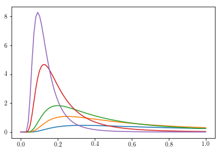

```python
x = np.linspace(0.0001,1,100)
plt.plot(x, inv_chi_square(x, 1.))
plt.plot(x, inv_chi_square(x, 2.))
plt.plot(x, inv_chi_square(x, 3.))
plt.plot(x, inv_chi_square(x, 6.))
plt.plot(x, inv_chi_square(x, 9.))
plt.show()
```

## Scaled Inverse Chi-Square Distribution

$y \sim \textbf{scaled\_inv\_chi\_square}(\textit{nu, sigma})$

```python
from scipy.special import gamma as gammafn
def scaled_inv_chi_square(x, nu, sigma):
    A = ((nu/2)**(nu/2) / gammafn(nu/2)) * sigma**nu * x**-(nu/2 +1)
    return A * np.exp(-(nu*sigma**2)/(2*x))
```

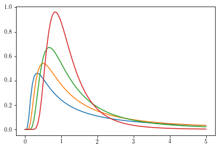

```python
x = np.linspace(0.0001,5,100)
plt.plot(x, scaled_inv_chi_square(x, 1., 1.))
plt.plot(x, scaled_inv_chi_square(x, 2., 1.))
plt.plot(x, scaled_inv_chi_square(x, 4., 1.))
plt.plot(x, scaled_inv_chi_square(x, 10., 1.))
plt.show()
```

## Exponential Distribution

$y \sim \textbf{exponential}(\textit{beta})$

```python
def exponential(x, beta):
    return beta * np.exp(-beta*x)
```

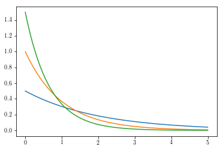

```python
x = np.linspace(0.0001,5,100)
plt.plot(x, exponential(x, 0.5))
plt.plot(x, exponential(x, 1.))
plt.plot(x, exponential(x, 1.5))
plt.show()
```

## Gamma Distribution

$y \sim \textbf{gamma}(\textit{alpha, beta})$

```python
from scipy.special import gamma as gammafn
def gamma(x, alpha, beta):
    return ((beta**alpha)/gammafn(alpha)) * x**(alpha-1) * np.exp(-beta*x)
```

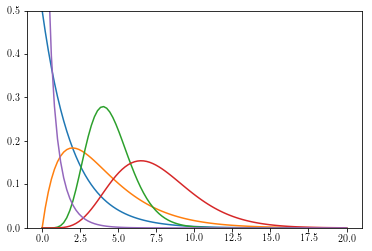

```python
x = np.linspace(0.0001, 20, 100)
plt.plot(x, gamma(x, 1., 1./2.))
plt.plot(x, gamma(x, 2., 1./2.))
plt.plot(x, gamma(x, 9., 1./.5))
plt.plot(x, gamma(x, 7.5, 1./1.))
plt.plot(x, gamma(x, .5, 1./1.))
plt.ylim(0.,0.5)
plt.show()
```

## Inverse Gamma Distribution

$y \sim \textbf{inv\_gamma}(\textit{alpha, beta})$

```python
from scipy.special import gamma as gammafn
def inv_gamma(x, alpha, beta):
    return ((beta**alpha)/gammafn(alpha)) * x**-(alpha+1) * np.exp(-beta*(1/x))
```

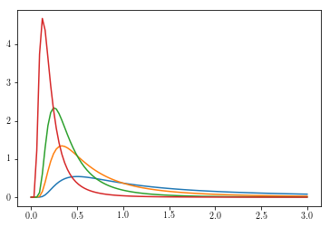

```python
x = np.linspace(0.0001, 3, 100)
plt.plot(x, inv_gamma(x, 1., 1.))
plt.plot(x, inv_gamma(x, 2., 1.))
plt.plot(x, inv_gamma(x, 3., 1.))
plt.plot(x, inv_gamma(x, 3., .5))
plt.show()
```

## Weibull Distribution

$y \sim \textbf{weibull}(\textit{alpha, sigma})$

```python
def weibull(x, alpha, sigma):
    return (alpha/sigma)*(x/sigma)**(alpha-1) * np.exp(-(x/sigma)**alpha)
```

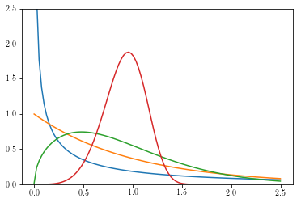

```python
x = np.linspace(0.0001, 2.5, 100)
plt.plot(x, weibull(x, 0.5, 1.))
plt.plot(x, weibull(x, 1., 1.))
plt.plot(x, weibull(x, 1.5, 1.))
plt.plot(x, weibull(x, 5., 1.))
plt.ylim(0., 2.5)
plt.show()
```

## Frechet Distribution

$y \sim \textbf{frechet}(\textit{alpha, sigma})$

```python
def frechet(x, alpha, sigma):
    return (alpha/sigma)*(x/sigma)**(-alpha-1) *np.exp(-(x/sigma)**-alpha)
```

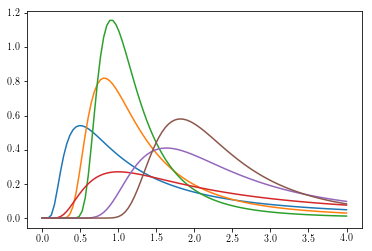

```python
x = np.linspace(0.0001, 4., 100)
plt.plot(x, frechet(x, 1., 1.))
plt.plot(x, frechet(x, 2, 1.))
plt.plot(x, frechet(x, 3, 1.))
plt.plot(x, frechet(x, 1, 2.))
plt.plot(x, frechet(x, 2, 2.))
plt.plot(x, frechet(x, 3, 2.))
plt.show()
```

# Non-negative Continuous Distributions

## Rayleigh Distribution

$y \sim \textbf{rayleigh}(\textit{sigma})$

```python
def rayleigh(x, sigma):
    return (x/sigma**2)*np.exp(-x**2/(2*sigma**2))
```

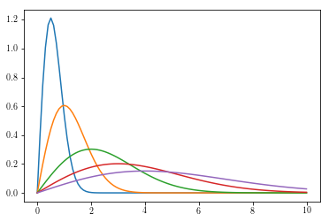

```python
x = np.linspace(0., 10., 100)
plt.plot(x, rayleigh(x, .5))
plt.plot(x, rayleigh(x, 1.))
plt.plot(x, rayleigh(x, 2.))
plt.plot(x, rayleigh(x, 3.))
plt.plot(x, rayleigh(x, 4.))
plt.show()
```

# Positive Lower Bounded Probabilities

## Pareto Distribution

$y \sim \textbf{pareto}(\textit{y_min, alpha})$

```python
def pareto(x, x_min, alpha):
    return (alpha*x_min**alpha)/(x**(alpha+1))
```

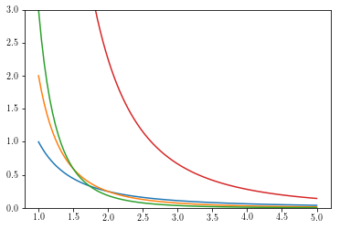

```python
x = np.linspace(1., 5., 100)
plt.plot(x, pareto(x, 1., 1.))
plt.plot(x, pareto(x, 1., 2.))
plt.plot(x, pareto(x, 1., 3.))
plt.plot(x, pareto(x, 3., 2.))
plt.ylim(0.,3.)
plt.show()
```

## Pareto Type 2 (Lomax) Distribution

$y \sim \textbf{pareto\_type\_2}(\textit{mu, lambda, alpha})$

```python
def pareto_type_2(x, mu, lambd, alpha):
    return (alpha/lambd)*(1+((x-mu)/lambd))**(-(alpha+1))
```

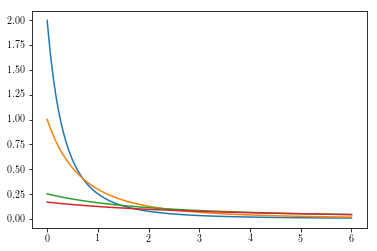

```python
x = np.linspace(0., 6., 100)
plt.plot(x, pareto_type_2(x, 0., 1., 2.))
plt.plot(x, pareto_type_2(x, 0., 2., 2.))
plt.plot(x, pareto_type_2(x, 0., 4., 1.))
plt.plot(x, pareto_type_2(x, 0., 6., 1.))
plt.show()
```

# Continuous Distributions on [0, 1]

## Beta Distribution

$y \sim \textbf{beta}(\textit{alpha, beta})$

```python
from scipy.special import beta as betafn
def beta(theta, alpha, beta):
    return (1/betafn(alpha, beta))*x**(alpha-1) * (1-x)**(beta-1)
```

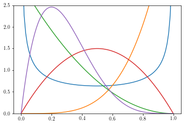

```python
x = np.linspace(0.0001, 0.9999, 100)
plt.plot(x, beta(x, .5, .5))
plt.plot(x, beta(x, 5., 1.))
plt.plot(x, beta(x, 1., 3.))
plt.plot(x, beta(x, 2., 2.))
plt.plot(x, beta(x, 2., 5.))
plt.ylim(0., 2.5)
plt.show()
```

## Thats all folks!

Everything else in the [reference guide](http://mc-stan.org/users/documentation/) is slightly above my ability and need to understand right now. Feel free to add them in though, if you find yourself using them!